# Reproducible Research: Peer Assessment 1

```r
library(ggplot2)
```

## Loading and preprocessing the data

The data for this assignment can be downloaded from the course web site:

*Dataset*: Activity monitoring data.

The variables included in this dataset are:

*steps*: Number of steps taking in a 5-minute interval (missing values are coded as NA).

*date*: The date on which the measurement was taken in YYYY-MM-DD format.

*interval*: Identifier for the 5-minute interval in which measurement was taken.

```r
activity = read.csv('activity.csv', header = T)
data = as.data.frame(activity[complete.cases(activity), ])
```

## What is mean total number of steps taken per day?

Calculate the total number of steps taken per day

```r
total.steps = tapply(data$steps, data$date, sum)
```

Make a histogram of the total number of steps taken each day

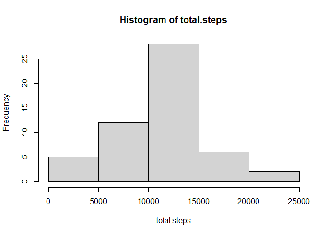

```r
hist(total.steps)
```

```r
mean = mean(total.steps, na.rm = TRUE)
median = median(total.steps, na.rm = TRUE)
```

## What is the average daily activity pattern?

Make a time series plot (i.e.type = “l”) of the 5-minute interval (x-axis) and the average number of steps taken, averaged across all days (y-axis)

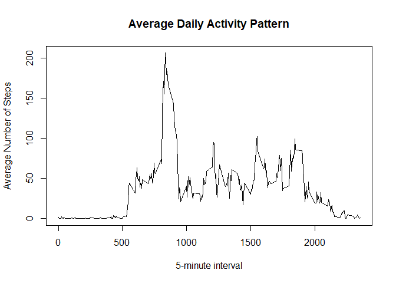

```r
data.plot = aggregate(data$steps, by = list(data$interval), FUN = mean)
plot(data.plot[, 1], data.plot[, 2], type = "l", xlab = "5-minute interval",
     ylab = "Average Number of Steps", main = "Average Daily Activity Pattern")
```

Which 5-minute interval, on average across all the days in the dataset, contains the maximum number of steps?

```r
data.plot[which.max(data.plot[, 2]), 1]
```

```
## [1] 835
```

## Imputing missing values

Calculate and report the total number of missing values in the dataset (i.e. the total number of rows with NAs)

```r
sum(!complete.cases(activity))
```

```
## [1] 2304
```

Devise a strategy for filling in all of the missing values in the dataset. The strategy does not need to be sophisticated. For example, you could use the mean/median for that day, or the mean for that 5-minute interval, etc. Create a new dataset that is equal to the original dataset but with the missing data filled in.

```r
missing = activity
missing[is.na(missing$steps), "steps"] = 0
no.missing = aggregate(steps ~ date, missing, sum)
```

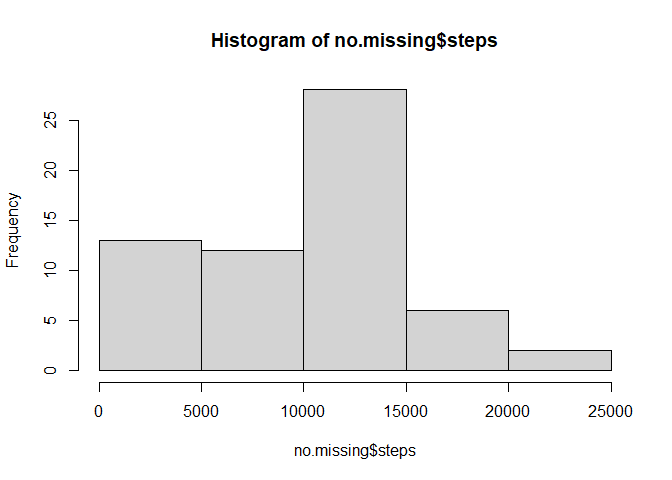

```r
hist(no.missing$steps)
```

```r
mean(no.missing$steps)
```

```
## [1] 9354.23
```

```r
median(no.missing$steps)
```

```
## [1] 10395
```

## Are there differences in activity patterns between weekdays and weekends?

Create a new factor variable in the dataset with two levels – “weekday” and “weekend” indicating whether a given date is a weekday or weekend day.

```r
days.ends = data.table::fread(input = 'activity.csv')
days.ends[, date := as.POSIXct(date, format = "%Y-%m-%d")]
days.ends[, `Day of Week`:= weekdays(x = date)]
days.ends[grepl(pattern = "lunes|martes|miércoles|jueves|viernes", x = `Day of Week`), "weekday or weekend"] = "weekday"
days.ends[grepl(pattern = "sábado|domingo", x = `Day of Week`), "weekday or weekend"] = "weekend"
days.ends[, `weekday or weekend` := as.factor(`weekday or weekend`)]
head(days.ends, 10)
```

```
##     steps       date interval Day of Week weekday or weekend
##  1:    NA 2012-10-01        0       lunes            weekday
##  2:    NA 2012-10-01        5       lunes            weekday
##  3:    NA 2012-10-01       10       lunes            weekday
##  4:    NA 2012-10-01       15       lunes            weekday
##  5:    NA 2012-10-01       20       lunes            weekday
##  6:    NA 2012-10-01       25       lunes            weekday
##  7:    NA 2012-10-01       30       lunes            weekday
##  8:    NA 2012-10-01       35       lunes            weekday
##  9:    NA 2012-10-01       40       lunes            weekday
## 10:    NA 2012-10-01       45       lunes            weekday
```

Make a panel plot containing a time series plot (i.e. type = “l”) of the 5-minute interval (x-axis) and the average number of steps taken, averaged across all weekday days or weekend days (y-axis). See the README file in the GitHub repository to see an example of what this plot should look like using simulated data.

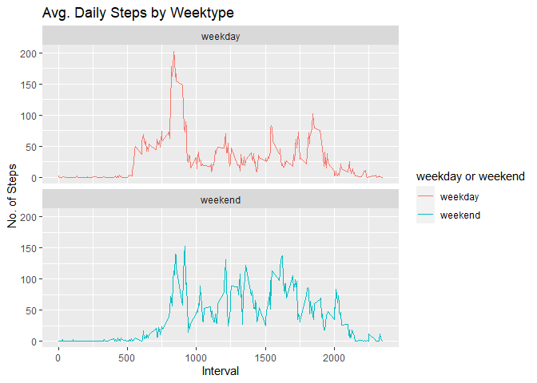

```r
days.ends[is.na(steps), "steps"] =
    days.ends[, c(lapply(.SD, median, na.rm = TRUE)), .SDcols = c("steps")]
ts = days.ends[, c(lapply(.SD, mean, na.rm = TRUE)), .SDcols = c("steps"), by = .(interval, `weekday or weekend`)]
ggplot(ts , aes(x = interval , y = steps, color=`weekday or weekend`)) +
    geom_line() +
    labs(title = "Avg. Daily Steps by Weektype", x = "Interval", y = "No. of Steps") +
    facet_wrap(~`weekday or weekend` , ncol = 1, nrow=2)
```